# Assignment 2

Author

Norma Marshall

For this assignment, we will be analyzing data from USC’s Children’s Health Study. The learning objectives are to conduct data wrangling and visualize the data with key questions in mind.

# Data Wrangling

You will need to download two datasets from https://github.com/USCbiostats/data-science-data. The individual and regional CHS datasets in 01_chs. The individual data includes personal and health characteristics of children in 12 communities across Southern California. The regional data include air quality measurements at the community level. Once downloaded, you can merge these datasets using the location variable. Once combined, you will need to do the following:

```r
library(tidyverse)
library(leaflet)
```

```r
chs_ind <- read.csv("chs_individual.csv")
chs_reg <- read.csv("chs_regional.csv")
chs <- merge(chs_ind, chs_reg, by = "townname", all.x = TRUE)
head(chs)
```

```
  townname sid male race hispanic    agepft height weight      bmi asthma
1   Alpine 841    1    W        1 10.548939    150     78 15.75758      0
2   Alpine 835    0    W        0 10.099932    143     69 15.33749      0
3   Alpine 838    0    O        1  9.486653    133     62 15.93183      0
4   Alpine 840    0    W        0  9.965777    146     78 16.63283      0
5   Alpine 865    0    W        0 10.039699    162    140 24.24797      1
6   Alpine 867    0    W        1  9.957563    141     94 21.49151      0
  active_asthma father_asthma mother_asthma wheeze hayfever allergy educ_parent
1             0             0             0      0        0       0           5
2             0             0             0      0        0       1           3
3             0             0             0      0        0       0           4
4             0             0             0      0        0       0          NA
5             1             0             0      1        0       1           3
6             0            NA             0      0        0       0           5
  smoke pets gasstove      fev      fvc     mmef pm25_mass pm25_so4 pm25_no3
```

[output cut: 27 more lines]

1. After merging the data, make sure you don’t have any duplicates by counting the number of rows. Make sure it matches.
- In the case of missing values, impute data using the average amongst individuals with the same values for the “male” and “hispanic” variables. For categorical variables, take the mode. If you are interested (and feel adventurous) in the theme of Data Imputation, take a look at this paper on “Multiple Imputation” using the Amelia R package here.

```r
print(nrow(chs_ind))
```

```
[1] 1200
```

```r
print(nrow(chs))
```

```
[1] 1200
```

```r
summary(chs)
```

```
   townname              sid              male            race
 Length:1200        Min.   :   1.0   Min.   :0.0000   Length:1200
 Class :character   1st Qu.: 528.8   1st Qu.:0.0000   Class :character
 Mode  :character   Median :1041.5   Median :0.0000   Mode  :character
                    Mean   :1037.5   Mean   :0.4917
                    3rd Qu.:1554.2   3rd Qu.:1.0000
                    Max.   :2053.0   Max.   :1.0000

    hispanic          agepft           height        weight
 Min.   :0.0000   Min.   : 8.961   Min.   :114   Min.   : 42.00
 1st Qu.:0.0000   1st Qu.: 9.610   1st Qu.:135   1st Qu.: 65.00
 Median :0.0000   Median : 9.906   Median :139   Median : 74.00
 Mean   :0.4342   Mean   : 9.924   Mean   :139   Mean   : 79.33
 3rd Qu.:1.0000   3rd Qu.:10.177   3rd Qu.:143   3rd Qu.: 89.00
 Max.   :1.0000   Max.   :12.731   Max.   :165   Max.   :207.00
                  NA's   :89       NA's   :89    NA's   :89
      bmi            asthma       active_asthma  father_asthma
 Min.   :11.30   Min.   :0.0000   Min.   :0.00   Min.   :0.00000
 1st Qu.:15.78   1st Qu.:0.0000   1st Qu.:0.00   1st Qu.:0.00000
 Median :17.48   Median :0.0000   Median :0.00   Median :0.00000
 Mean   :18.50   Mean   :0.1463   Mean   :0.19   Mean   :0.08318
 3rd Qu.:20.35   3rd Qu.:0.0000   3rd Qu.:0.00   3rd Qu.:0.00000
 Max.   :41.27   Max.   :1.0000   Max.   :1.00   Max.   :1.00000
 NA's   :89      NA's   :31                      NA's   :106
 mother_asthma        wheeze          hayfever         allergy
 Min.   :0.0000   Min.   :0.0000   Min.   :0.0000   Min.   :0.0000
 1st Qu.:0.0000   1st Qu.:0.0000   1st Qu.:0.0000   1st Qu.:0.0000
 Median :0.0000   Median :0.0000   Median :0.0000   Median :0.0000
 Mean   :0.1023   Mean   :0.3313   Mean   :0.1747   Mean   :0.2929
 3rd Qu.:0.0000   3rd Qu.:1.0000   3rd Qu.:0.0000   3rd Qu.:1.0000
 Max.   :1.0000   Max.   :1.0000   Max.   :1.0000   Max.   :1.0000
 NA's   :56       NA's   :71       NA's   :118      NA's   :63
  educ_parent        smoke             pets           gasstove
 Min.   :1.000   Min.   :0.0000   Min.   :0.0000   Min.   :0.0000
 1st Qu.:2.000   1st Qu.:0.0000   1st Qu.:1.0000   1st Qu.:1.0000
 Median :3.000   Median :0.0000   Median :1.0000   Median :1.0000
 Mean   :2.797   Mean   :0.1638   Mean   :0.7667   Mean   :0.7815
 3rd Qu.:3.000   3rd Qu.:0.0000   3rd Qu.:1.0000   3rd Qu.:1.0000
 Max.   :5.000   Max.   :1.0000   Max.   :1.0000   Max.   :1.0000
 NA's   :64      NA's   :40                        NA's   :33
```

[output cut: 48 more lines]

```
     iacid           oacid        total_acids          lon
 Min.   :0.760   Min.   :1.090   Min.   : 1.520   Min.   :-120.7
 1st Qu.:1.835   1st Qu.:2.978   1st Qu.: 4.930   1st Qu.:-118.8
 Median :2.825   Median :4.135   Median : 6.370   Median :-117.7
 Mean   :2.788   Mean   :4.342   Mean   : 6.708   Mean   :-118.3
 3rd Qu.:3.817   3rd Qu.:5.982   3rd Qu.: 9.395   3rd Qu.:-117.4
 Max.   :4.620   Max.   :7.400   Max.   :11.430   Max.   :-116.8

      lat
 Min.   :32.84
 1st Qu.:33.93
 Median :34.10
 Mean   :34.20
 3rd Qu.:34.65
 Max.   :35.49
```

> Based on a quick summary of all the variables in this dataset, there are several missing values for variables including agepft, height, weight, BMI, asthma, father_asthma, mother_asthma, wheeze, hayfever, alelrgy, educ_parent, smoke, gassstove, fev, fvc, mmef, no_24fr, and pm2_5_fr.

```r
calculate_mode <- function(x) {
  tbl <- table(x)
  mode_value <- as.numeric(names(tbl[tbl == max(tbl)]))
  if (length(mode_value) == 0) return(NA) else return(mode_value)
}

# separte continous and categorical
continuous_vars <- c("agepft", "height", "weight", "bmi", "fev", "fvc", "mmef", "no_24hr", "pm2_5_fr")
categorical_vars <- c("asthma", "father_asthma", "mother_asthma", "wheeze", "hayfever", "allergy", "educ_parent", "smoke", "gasstove")

# impute missing values for continuous variables  - mean for male and hispanics
chs <- chs %>%
  group_by(male, hispanic) %>%
  mutate(across(all_of(continuous_vars), ~ ifelse(is.na(.), mean(., na.rm = TRUE), .)))

# impute missing values for categorical variables - modes for male and hispanic
chs <- chs %>%
  group_by(male, hispanic) %>%
  mutate(across(all_of(categorical_vars), ~ ifelse(is.na(.), calculate_mode(.), .)))

# Ungroup the dataset - doesn't affect stuff later
chs <- ungroup(chs)

#  summary to check
summary(chs)
```

```
   townname              sid              male            race
 Length:1200        Min.   :   1.0   Min.   :0.0000   Length:1200
 Class :character   1st Qu.: 528.8   1st Qu.:0.0000   Class :character
 Mode  :character   Median :1041.5   Median :0.0000   Mode  :character
                    Mean   :1037.5   Mean   :0.4917
                    3rd Qu.:1554.2   3rd Qu.:1.0000
                    Max.   :2053.0   Max.   :1.0000
    hispanic          agepft           height        weight
 Min.   :0.0000   Min.   : 8.961   Min.   :114   Min.   : 42.00
 1st Qu.:0.0000   1st Qu.: 9.632   1st Qu.:135   1st Qu.: 66.00
 Median :0.0000   Median : 9.907   Median :139   Median : 76.00
 Mean   :0.4342   Mean   : 9.923   Mean   :139   Mean   : 79.31
 3rd Qu.:1.0000   3rd Qu.:10.155   3rd Qu.:143   3rd Qu.: 87.00
 Max.   :1.0000   Max.   :12.731   Max.   :165   Max.   :207.00
      bmi            asthma       active_asthma  father_asthma
 Min.   :11.30   Min.   :0.0000   Min.   :0.00   Min.   :0.00000
 1st Qu.:15.96   1st Qu.:0.0000   1st Qu.:0.00   1st Qu.:0.00000
 Median :17.81   Median :0.0000   Median :0.00   Median :0.00000
 Mean   :18.50   Mean   :0.1425   Mean   :0.19   Mean   :0.07583
 3rd Qu.:19.99   3rd Qu.:0.0000   3rd Qu.:0.00   3rd Qu.:0.00000
 Max.   :41.27   Max.   :1.0000   Max.   :1.00   Max.   :1.00000
 mother_asthma        wheeze          hayfever         allergy
 Min.   :0.0000   Min.   :0.0000   Min.   :0.0000   Min.   :0.0000
 1st Qu.:0.0000   1st Qu.:0.0000   1st Qu.:0.0000   1st Qu.:0.0000
 Median :0.0000   Median :0.0000   Median :0.0000   Median :0.0000
 Mean   :0.0975   Mean   :0.3117   Mean   :0.1575   Mean   :0.2775
 3rd Qu.:0.0000   3rd Qu.:1.0000   3rd Qu.:0.0000   3rd Qu.:1.0000
 Max.   :1.0000   Max.   :1.0000   Max.   :1.0000   Max.   :1.0000
  educ_parent        smoke             pets           gasstove
 Min.   :1.000   Min.   :0.0000   Min.   :0.0000   Min.   :0.0000
 1st Qu.:2.000   1st Qu.:0.0000   1st Qu.:1.0000   1st Qu.:1.0000
 Median :3.000   Median :0.0000   Median :1.0000   Median :1.0000
 Mean   :2.808   Mean   :0.1583   Mean   :0.7667   Mean   :0.7875
 3rd Qu.:3.000   3rd Qu.:0.0000   3rd Qu.:1.0000   3rd Qu.:1.0000
 Max.   :5.000   Max.   :1.0000   Max.   :1.0000   Max.   :1.0000
      fev              fvc            mmef          pm25_mass
 Min.   : 984.8   Min.   : 895   Min.   : 757.6   Min.   : 5.960
 1st Qu.:1827.6   1st Qu.:2065   1st Qu.:2043.7   1st Qu.: 7.615
 Median :2016.4   Median :2282   Median :2392.1   Median :10.545
 Mean   :2030.1   Mean   :2322   Mean   :2398.6   Mean   :14.362
```

[output cut: 36 more lines]

```
 Max.   :37.97   Max.   :70.39   Max.   :42.950   Max.   :31.55
     iacid           oacid        total_acids          lon
 Min.   :0.760   Min.   :1.090   Min.   : 1.520   Min.   :-120.7
 1st Qu.:1.835   1st Qu.:2.978   1st Qu.: 4.930   1st Qu.:-118.8
 Median :2.825   Median :4.135   Median : 6.370   Median :-117.7
 Mean   :2.788   Mean   :4.342   Mean   : 6.708   Mean   :-118.3
 3rd Qu.:3.817   3rd Qu.:5.982   3rd Qu.: 9.395   3rd Qu.:-117.4
 Max.   :4.620   Max.   :7.400   Max.   :11.430   Max.   :-116.8
      lat
 Min.   :32.84
 1st Qu.:33.93
 Median :34.10
 Mean   :34.20
 3rd Qu.:34.65
 Max.   :35.49
```

> Imputing variables was successful. No missing variables.
2. Create a new categorical variable named “obesity_level” using the BMI measurement (underweight BMI<14; normal BMI 14-22; overweight BMI 22-24; obese BMI>24). To make sure the variable is rightly coded, create a summary table that contains the minimum BMI, maximum BMI, and the total number of observations per category.

```r
chs <- chs %>%
  mutate(obesity_level = case_when(
    bmi < 14 ~ "underweight",
    bmi >= 14 & bmi < 22 ~ "normal",
    bmi >= 22 & bmi <= 24 ~ "overweight",
    bmi > 24 ~ "obese",
    TRUE ~ NA_character_
  ))
```

```r
bmi_table <- chs %>%
  group_by(obesity_level) %>%
  summarise(
    min_bmi = min(bmi),
    max_bmi = max(bmi),
    total_observations = n()
  )
print(bmi_table)
```

```
# A tibble: 4 × 4
  obesity_level min_bmi max_bmi total_observations
  <chr>           <dbl>   <dbl>              <int>
1 normal           14.0    22.0                975
2 obese            24.0    41.3                103
3 overweight       22.0    24.0                 87
4 underweight      11.3    14.0                 35
```

3. Create another categorical variable named “smoke_gas_exposure” that summarizes “Second Hand Smoke” and “Gas Stove.” The variable should have four categories in total.

```r
chs <- chs %>%
  mutate(smoke_gas_exposure = case_when(
    smoke == 0 & gasstove == 0 ~ "Neither",
    smoke == 1 & gasstove == 0 ~ "Smoke Only",
    smoke == 0 & gasstove == 1 ~ "Gas Stove Only",
    smoke == 1 & gasstove == 1 ~ "Both"
  ))

table(chs$smoke_gas_exposure)
```

```
          Both Gas Stove Only        Neither     Smoke Only
           154            791            219             36
```

4. Create four summary tables showing the average (or proportion, if binary) and sd of “Forced expiratory volume in 1 second (ml)” (an asthma indicator) by town, sex, obesity level, and “smoke_gas_exposure.”

```r
townname_summary <- chs %>%
  group_by(townname) %>%
  summarize(
    avg_fev = mean(fev, na.rm = TRUE),
    sd_fev = sd(fev, na.rm = TRUE),
    proportion_asthma = mean(asthma, na.rm = TRUE)
  ) %>%
  ungroup()
print(townname_summary)
```

```
# A tibble: 12 × 4
   townname      avg_fev sd_fev proportion_asthma
   <chr>           <dbl>  <dbl>             <dbl>
 1 Alpine          2087.   291.             0.11
 2 Atascadero      2076.   324.             0.25
 3 Lake Elsinore   2039.   304.             0.12
 4 Lake Gregory    2085.   320.             0.15
 5 Lancaster       2003.   317.             0.16
 6 Lompoc          2034.   351.             0.11
 7 Long Beach      1986.   319.             0.13
 8 Mira Loma       1985.   325.             0.15
 9 Riverside       1990.   278.             0.11
10 San Dimas       2027.   319.             0.17
11 Santa Maria     2026.   312.             0.13
12 Upland          2024.   343.             0.120
```

```r
sex_summary <- chs %>%
  group_by(male) %>%
  summarize(
    avg_fev = mean(fev, na.rm = TRUE),
    sd_fev = sd(fev, na.rm = TRUE),
    proportion_asthma = mean(asthma, na.rm = TRUE)
  ) %>%
  ungroup()
print(sex_summary)
```

```
# A tibble: 2 × 4
   male avg_fev sd_fev proportion_asthma
  <int>   <dbl>  <dbl>             <dbl>
1     0   1959.   312.             0.118
2     1   2104.   308.             0.168
```

```r
obesity_level_summary <- chs %>%
  group_by(obesity_level) %>%
  summarize(
    avg_fev = mean(fev, na.rm = TRUE),
    sd_fev = sd(fev, na.rm = TRUE),
    proportion_asthma = mean(asthma, na.rm = TRUE)
  ) %>%
  ungroup()
print(obesity_level_summary)
```

```
# A tibble: 4 × 4
  obesity_level avg_fev sd_fev proportion_asthma
  <chr>           <dbl>  <dbl>             <dbl>
1 normal          2000.   295.            0.136
2 obese           2266.   325.            0.204
3 overweight      2224.   317.            0.161
4 underweight     1698.   303.            0.0857
```

```r
smoke_gas_exposure_summary <- chs %>%
  group_by(smoke_gas_exposure) %>%
  summarize(
    avg_fev = mean(fev, na.rm = TRUE),
    sd_fev = sd(fev, na.rm = TRUE),
    proportion_asthma = mean(asthma, na.rm = TRUE)
  ) %>%
  ungroup()
print(smoke_gas_exposure_summary)
```

```
# A tibble: 4 × 4
  smoke_gas_exposure avg_fev sd_fev proportion_asthma
  <chr>                <dbl>  <dbl>             <dbl>
1 Both                 2025.   301.             0.123
2 Gas Stove Only       2023.   319.             0.145
3 Neither              2057.   329.             0.142
4 Smoke Only           2056.   296.             0.167
```

## Looking at the Data (EDA)

The primary questions of interest are:

1. What is the association between BMI and FEV (forced expiratory volume)?
2. What is the association between smoke and gas exposure and FEV?
3. What is the association between PM2.5 exposure and FEV? Follow the EDA checklist from week 3 and the previous assignment. Be sure to focus on the key variables.

### EDA Checklist (for reference)

1. Read in the data ( CHECK)
2. Check the size of the data (CHECK)
3. Examine the variables and their types (CHECK)

```r
str(chs)
```

```
tibble [1,200 × 51] (S3: tbl_df/tbl/data.frame)
 $ townname          : chr [1:1200] "Alpine" "Alpine" "Alpine" "Alpine" ...
 $ sid               : int [1:1200] 841 835 838 840 865 867 842 839 844 847 ...
 $ male              : int [1:1200] 1 0 0 0 0 0 1 0 1 1 ...
 $ race              : chr [1:1200] "W" "W" "O" "W" ...
 $ hispanic          : int [1:1200] 1 0 1 0 0 1 1 1 1 0 ...
 $ agepft            : num [1:1200] 10.55 10.1 9.49 9.97 10.04 ...
 $ height            : num [1:1200] 150 143 133 146 162 141 139 142 143 137 ...
 $ weight            : num [1:1200] 78 69 62 78 140 94 65 86 65 69 ...
 $ bmi               : num [1:1200] 15.8 15.3 15.9 16.6 24.2 ...
 $ asthma            : num [1:1200] 0 0 0 0 1 0 0 0 0 0 ...
 $ active_asthma     : int [1:1200] 0 0 0 0 1 0 0 0 0 0 ...
 $ father_asthma     : num [1:1200] 0 0 0 0 0 0 0 0 0 0 ...
 $ mother_asthma     : num [1:1200] 0 0 0 0 0 0 0 1 0 0 ...
 $ wheeze            : num [1:1200] 0 0 0 0 1 0 1 1 0 0 ...
```

[output cut: 37 more lines]

4. Look at the top and bottom of the data

```r
head(chs)
```

```
# A tibble: 6 × 51
  townname   sid  male race  hispanic agepft height weight   bmi asthma
  <chr>    <int> <int> <chr>    <int>  <dbl>  <dbl>  <dbl> <dbl>  <dbl>
1 Alpine     841     1 W            1  10.5     150     78  15.8      0
2 Alpine     835     0 W            0  10.1     143     69  15.3      0
3 Alpine     838     0 O            1   9.49    133     62  15.9      0
4 Alpine     840     0 W            0   9.97    146     78  16.6      0
5 Alpine     865     0 W            0  10.0     162    140  24.2      1
6 Alpine     867     0 W            1   9.96    141     94  21.5      0
# ℹ 41 more variables: active_asthma <int>, father_asthma <dbl>,
#   mother_asthma <dbl>, wheeze <dbl>, hayfever <dbl>, allergy <dbl>,
#   educ_parent <dbl>, smoke <dbl>, pets <int>, gasstove <dbl>, fev <dbl>,
#   fvc <dbl>, mmef <dbl>, pm25_mass <dbl>, pm25_so4 <dbl>, pm25_no3 <dbl>,
#   pm25_nh4 <dbl>, pm25_oc <dbl>, pm25_ec <dbl>, pm25_om <dbl>, pm10_oc <dbl>,
#   pm10_ec <dbl>, pm10_tc <dbl>, formic <dbl>, acetic <dbl>, hcl <dbl>,
#   hno3 <dbl>, o3_max <dbl>, o3106 <dbl>, o3_24 <dbl>, no2 <dbl>, …
```

```r
tail(chs)
```

```
# A tibble: 6 × 51
  townname   sid  male race  hispanic agepft height weight   bmi asthma
  <chr>    <int> <int> <chr>    <int>  <dbl>  <dbl>  <dbl> <dbl>  <dbl>
1 Upland    1866     0 O            1   9.81   139    60    14.1      0
2 Upland    1867     0 M            1   9.62   140    71    16.5      0
3 Upland    2033     0 M            0  10.1    130    67    18.0      0
4 Upland    2031     1 W            0   9.80   135    83    20.7      0
5 Upland    2032     1 W            0   9.55   137    59    14.3      0
6 Upland    2053     0 W            0   9.85   139.   77.4  18.1      0
# ℹ 41 more variables: active_asthma <int>, father_asthma <dbl>,
#   mother_asthma <dbl>, wheeze <dbl>, hayfever <dbl>, allergy <dbl>,
#   educ_parent <dbl>, smoke <dbl>, pets <int>, gasstove <dbl>, fev <dbl>,
#   fvc <dbl>, mmef <dbl>, pm25_mass <dbl>, pm25_so4 <dbl>, pm25_no3 <dbl>,
#   pm25_nh4 <dbl>, pm25_oc <dbl>, pm25_ec <dbl>, pm25_om <dbl>, pm10_oc <dbl>,
#   pm10_ec <dbl>, pm10_tc <dbl>, formic <dbl>, acetic <dbl>, hcl <dbl>,
#   hno3 <dbl>, o3_max <dbl>, o3106 <dbl>, o3_24 <dbl>, no2 <dbl>, …
```

5. Check your expectations

> A higher fev would indicate healthier lungs since they can expell more air duirng a breath. I would expect that having a gas stove (and the parciulate matter that comes from cooking with a gas stove) as well as exposure to second hand smoke would affect the lungs’ capacity to be as effective, thus resulting in lower FEV1 volume. In addition, I would also expect that a higher BMI, would also neegativly affect FEV1 as carrying more weight could affect one’s capacity to breath as easily.
6. Validate with an external source

> A 1999 meta analysis of 17 studies foudn a mean decrease in FEV1. with second hand smoke exposure. Another study found a negative associaton betwewen BMI and FEV1, across obese, overweight, and underweight subjects. Researchers found that as BMI increase, there is also a decrease in FEV1.
> - Bhatti U, Laghari ZA, Syed BM. Effect of Body Mass Index on respiratory parameters: A cross-sectional analytical Study. Pak J Med Sci. 2019 Nov-Dec;35(6):1724-1729. doi: 10.12669/pjms.35.6.746. PMID: 31777523; PMCID: PMC6861468.
> - Office on Smoking and Health (US). The Health Consequences of Involuntary Exposure to Tobacco Smoke: A Report of the Surgeon General. Atlanta (GA): Centers for Disease Control and Prevention (US); 2006.9, Respiratory Effects in Adults from Exposure to Secondhand Smoke. Available from: https://www.ncbi.nlm.nih.gov/books/NBK44316/#
7. Formulate a (simple) question (see research questions)

> What is the association between BMI, secondhand smoke and gas exposure at home, and particulate matter with FEV1?
8. Try the easy solution first

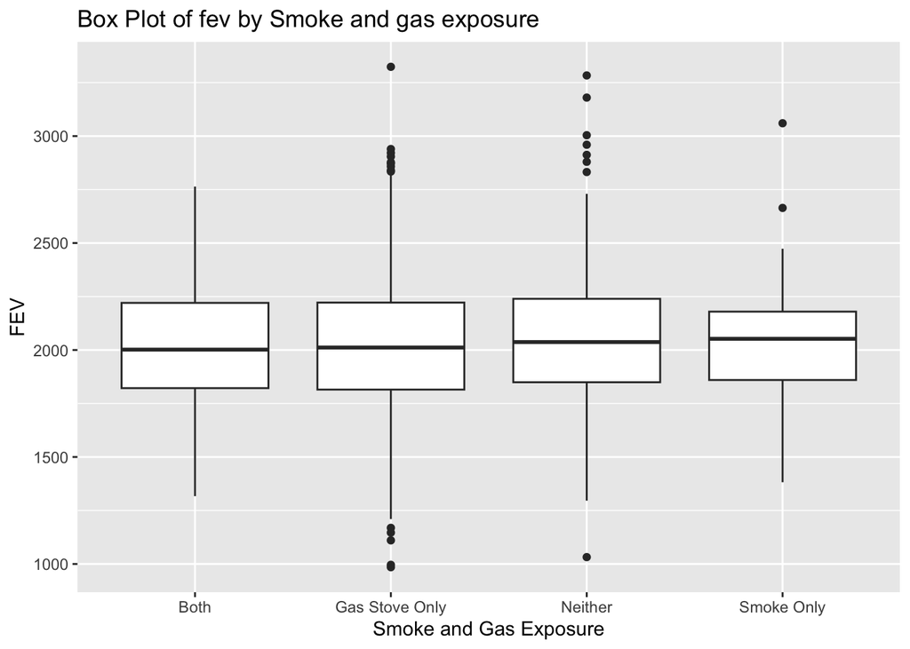

```r
library(ggplot2)
ggplot(chs, aes(x = smoke_gas_exposure, y = fev)) +
  geom_boxplot() +
  labs(
    title = "Box Plot of fev by Smoke and gas exposure",
    x = "Smoke and Gas Exposure",
    y = "FEV"
  )
```

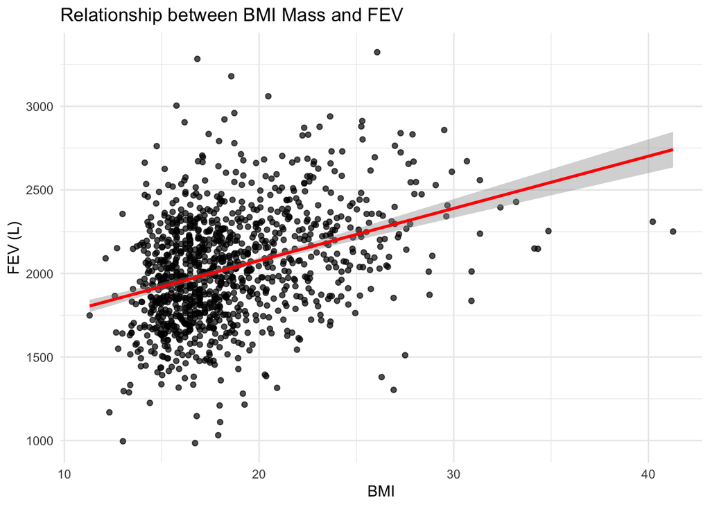

```r
ggplot(chs, aes(x = bmi, y = fev)) +
  geom_point(alpha = 0.7) +  # Scatter points with some transparency
  geom_smooth(method = "lm", color = "red") +
  labs(x = "BMI",
       y = "FEV (L)",
       title = "Relationship between BMI Mass and FEV") +
  theme_minimal() +
  theme(legend.position = "none")
```

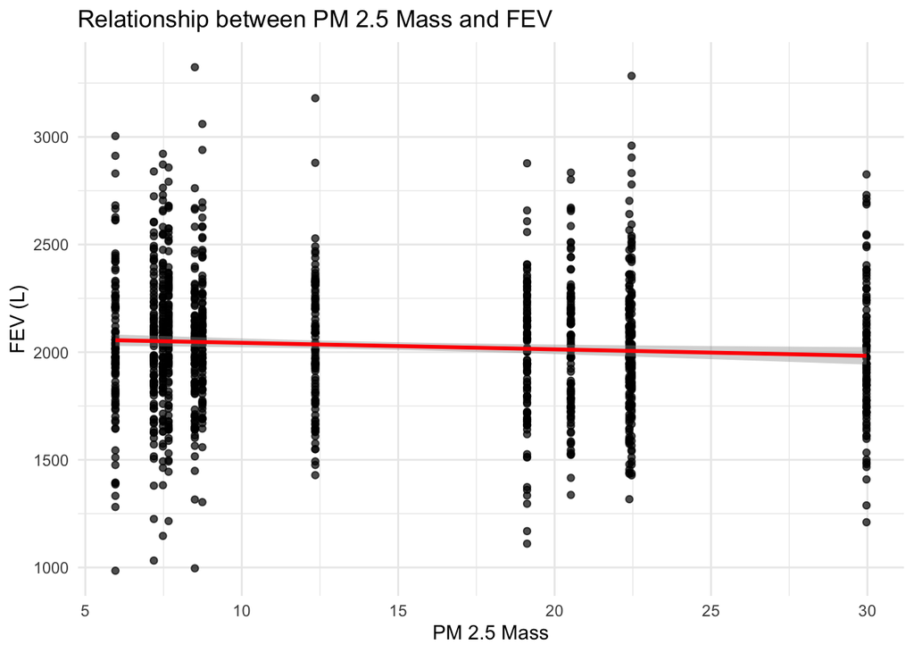

```r
ggplot(chs, aes(x = pm25_mass, y = fev)) +
  geom_point(alpha = 0.7) +  # Scatter points with some transparency
  geom_smooth(method = "lm", color = "red") +
  labs(x = "PM 2.5 Mass",
       y = "FEV (L)",
       title = "Relationship between PM 2.5 Mass and FEV") +
  theme_minimal() +
  theme(legend.position = "none")
```

> Based on some early graphs there apepars to be a sight negative association with pm2.5 mass and FEV, indicating that with the more PM2.5 exposure then the less forced expiratory volume in one second. This is the opposite for BMI where the higher the BMI, the greater the FEV1. However, most subjects bend to fall below 25 BMI, introducing greater variability in the relationship for those who are overweight and obese. The relationship is harder to tell with smoke and gas stove exposure as being exposed to both secondhand smoke and gas stoves, neither, or both result in around the same FEV, but with several outliers.
9. Challenge your solution

## Visualization

Create the following figures and interpret them. Be sure to include easily understandable axes, titles, and legends.

1. Facet plot showing scatterplots with regression lines of BMI vs FEV by “townname”.

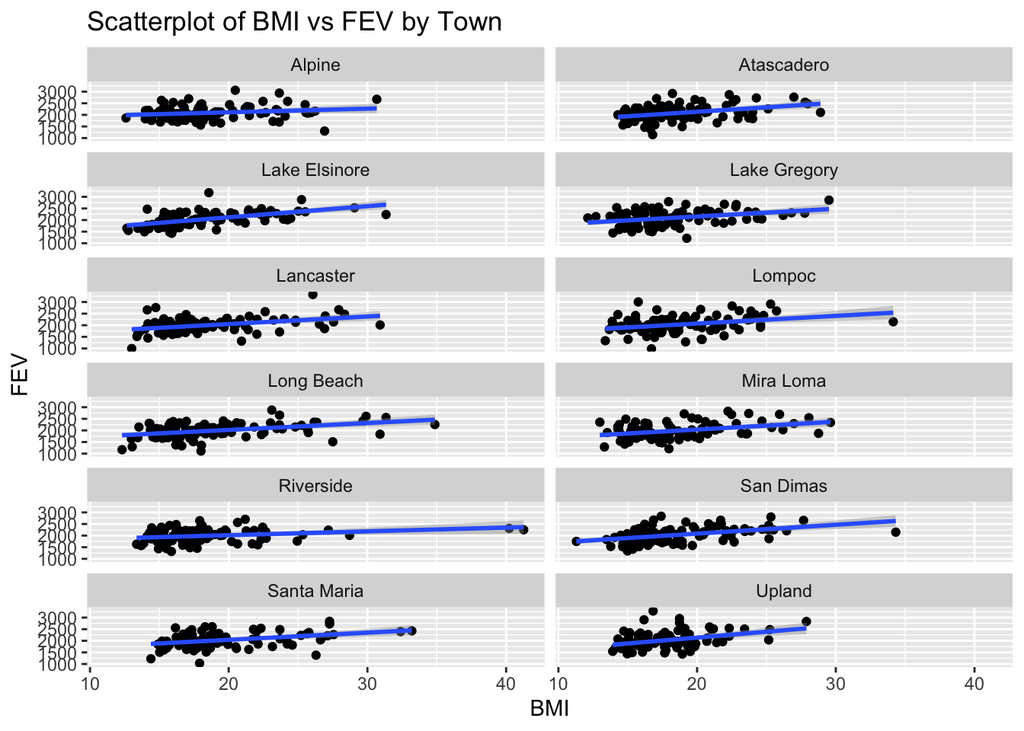

```r
ggplot(chs, aes(x = bmi, y = fev)) +
  geom_point() +
  geom_smooth(method = "lm") +
  labs(
    title = "Scatterplot of BMI vs FEV by Town",
    x = "BMI",
    y = "FEV"
  ) +
  facet_wrap(~ townname, ncol = 2)
```

> For each town there is a postive relationship between BMI and FEV. A few town including Mira Loma and Lake Gregory have more points scattered across the regression line, indicating more variablity in that relationship while towns such like Riverside have more results with lower BMI values. There a few extreme values across all the towns, hwower most subjects are below 25 BMI.

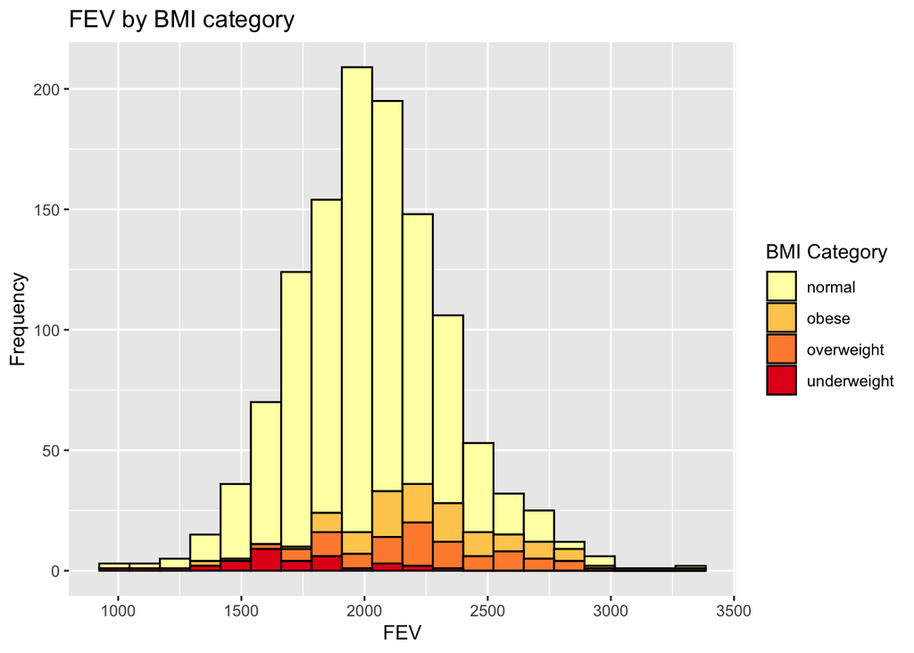

```r
ggplot(data = chs) +
  geom_histogram(mapping = aes(x = fev, fill = obesity_level), position = "stack", bins = 20, color = "black") +
  scale_fill_brewer(palette = "YlOrRd") +
  labs(
    title = "FEV by BMI category",
    x = "FEV",
    y = "Frequency",
    fill = "BMI Category")
```

> A majority of of subjects in are within the normal BMI categories. This makes sense as subjects in the normal BMI range represent the majority of this sample.In addtion, most subjects withhin normal BMI range are expreincing FEV values of below ~3000 with the majority being at around 2000.
3. Barchart of BMI by smoke/gas exposure.

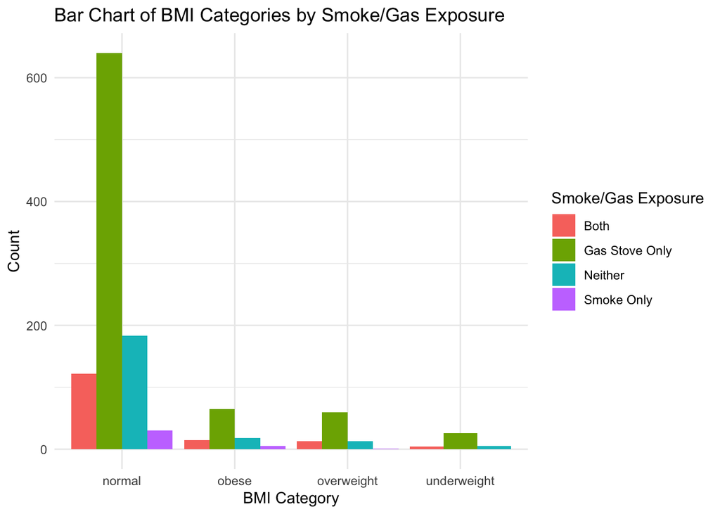

```r
ggplot(chs, aes(x = obesity_level, fill = smoke_gas_exposure)) +  #
  geom_bar(position = "dodge") +
  labs(x = "BMI Category", y = "Count",
       title = "Bar Chart of BMI Categories by Smoke/Gas Exposure",
       fill = "Smoke/Gas Exposure") +
  theme_minimal()
```

> This bar chart shows that most participants in the normal BMI category are exposed to gas stoves only. Exposure to Both smoke and gas stoves or neither are less common across all obesity levels, and participants in the obese and overweight categories are far fewer across all exposure types. There appears to be a notable concentration of normal BMI individuals exposed to gas stoves only.
4. Statistical summary graphs of FEV by BMI and FEV by smoke/gas exposure category.

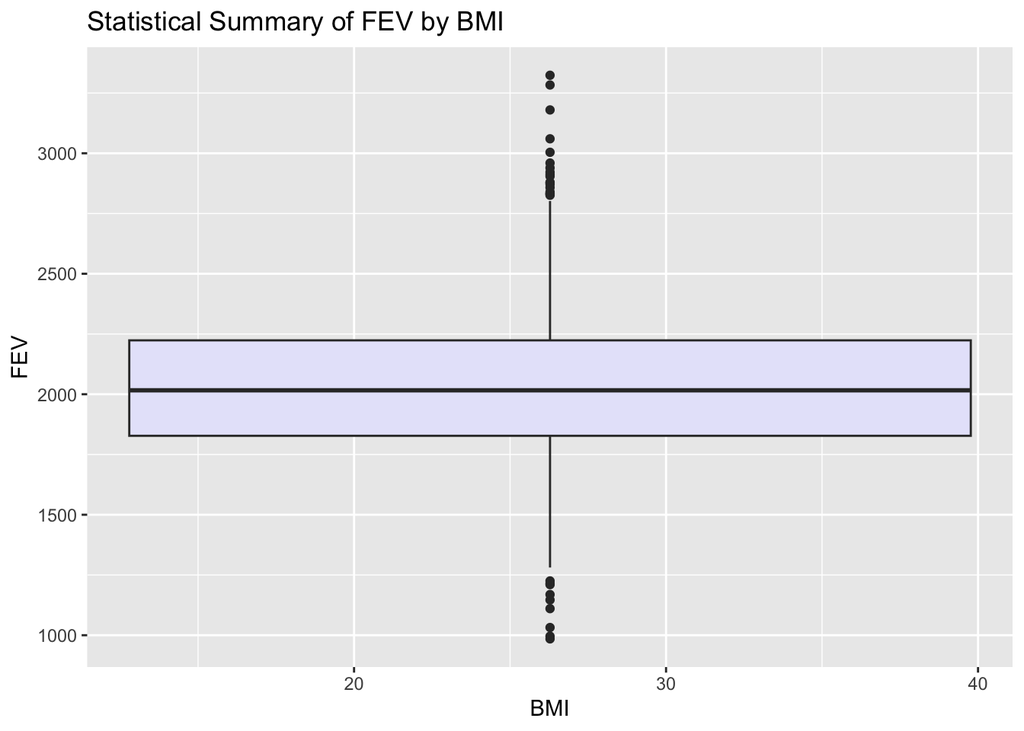

```r
ggplot(chs, aes(x = bmi, y = fev)) +
  geom_boxplot(fill = "lavender") +
  labs(
    title = "Statistical Summary of FEV by BMI",
    x = "BMI",
    y = "FEV"
  )
```

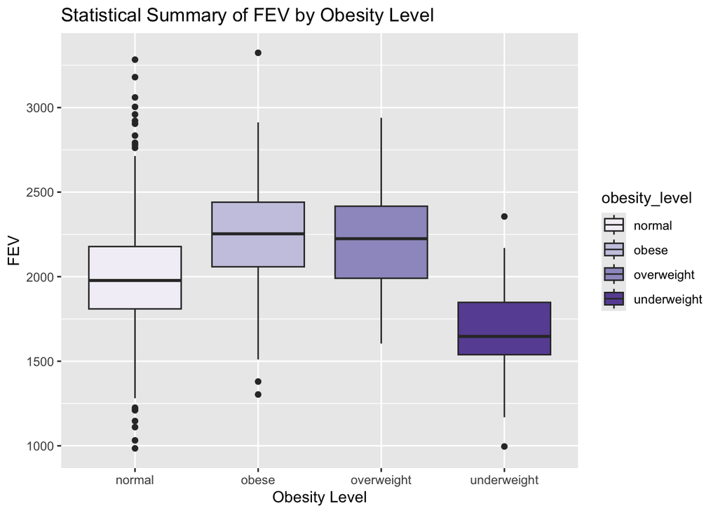

```r
ggplot(chs, aes(x = obesity_level, y = fev, fill = obesity_level)) +
  geom_boxplot() +
  labs(
    title = "Statistical Summary of FEV by Obesity Level",
    x = "Obesity Level",
    y = "FEV"
  ) +
  scale_fill_brewer(palette = "Purples")
```

> Overall median FEV tends to be at around 2000. However when this is broken down by obesity level, obese and overweight subjects had higher FEV1 than normal and underweight subjects, with underweight subjects having the lowest FEV out of the four groups.

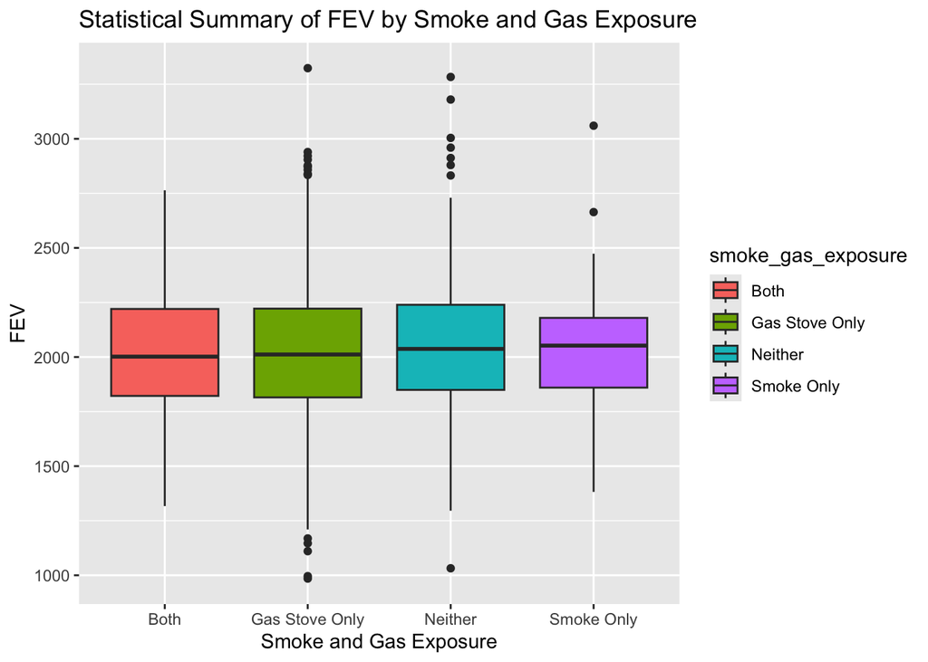

```r
ggplot(chs, aes(x = smoke_gas_exposure, y = fev, fill = smoke_gas_exposure)) +
  geom_boxplot() +
  labs(
    title = "Statistical Summary of FEV by Smoke and Gas Exposure",
    x = "Smoke and Gas Exposure",
    y = "FEV"
  )
```

> Across smoke and gas exposure, all four grups were very similiar in terms of median FEV values, however there is some variation in their range. Subjects with exposure to gas stoves only, second hand smoke only, or neither had several outliers with maximum and minimum FEV.
5. A map showing the concentrations of PM2.5 mass in each of the CHS communities.

```r
pm.pal <- colorNumeric(c('yellow', 'orange', 'red', 'black'), domain = chs$pm25_mass)


leafplot <- leaflet(chs) %>%
  addProviderTiles('CartoDB.Positron') %>%
  addCircles(
    lat = ~lat, lng = ~lon,
    label = ~paste0(round(pm25_mass, 2)),
    color = ~pm.pal(pm25_mass),
    opacity = 1, fillOpacity = 1
    ) %>%
  addLegend('bottomleft', pal = pm.pal, values = chs$pm25_mass,
          title = 'PM 2.5 Concentration in CHS Communities', opacity = 1)
leafplot
```

[interactive chart not shown]

> The map shows that PM2.5 concentrations are higher in more densely populated areas of Los Angeles. These levels are notably elevated near large, urban regions of the city, which aligns with the fact that PM2.5 is primarily generated by major pollution sources like power plants and vehicle emissions.
6. Choose a visualization to examine whether PM2.5 mass is associated with FEV.

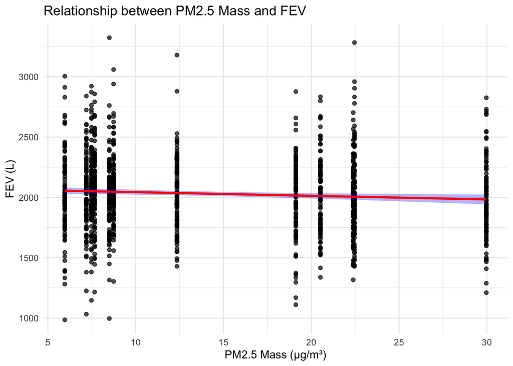

```r
ggplot(chs, aes(x = pm25_mass, y = fev)) +
  geom_point(alpha = 0.7) +  # Scatter points with some transparency
  geom_smooth(method = "lm", se = TRUE, color = "red", fill = "blue", alpha = 0.3) +  # Regression line with confidence interval
  labs(x = "PM2.5 Mass (µg/m³)",
       y = "FEV (L)",
       title = "Relationship between PM2.5 Mass and FEV") +
  theme_minimal() +
  theme(legend.position = "none")
```

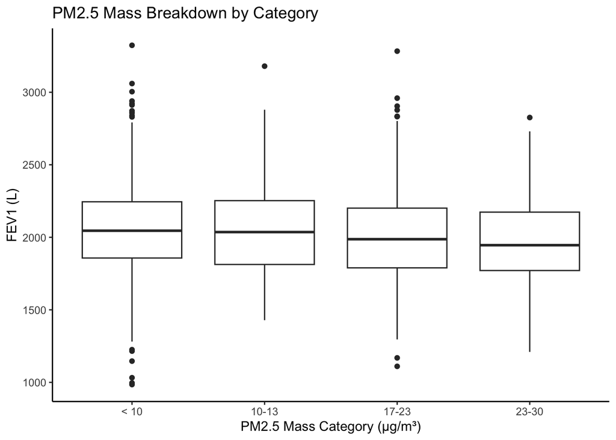

```r
chs$pm25_category <- cut(chs$pm25_mass,
                         breaks = c(-Inf, 10, 13, 17, 23, 30, Inf),
                         labels = c("< 10", "10-13", "13-17", "17-23", "23-30", "> 30"),
                         right = FALSE)

ggplot(chs, aes(x = pm25_category, y = fev)) +
  geom_boxplot() +
  labs(x = "PM2.5 Mass Category (µg/m³)",
       y = "FEV1 (L)",
       title = "PM2.5 Mass Breakdown by Category") +
  theme_classic()
```